# Webscrapping NBA

```python
from IPython.display import Image
Image(url="nba cover.jpg", width=500, height=300)
```

[figure not shown]

```python
Image(url="nba log.png", width=100, height=500)
```

[figure not shown]

### Explanation:

nba_api: This is a Python library specifically designed to access NBA data. It provides access to a variety of data endpoints made available by the NBA, such as player stats, team data, and game details. The library uses the NBA’s official stats API to retrieve data directly.

stats.endpoints: Within nba_api, the stats module contains various endpoints, each corresponding to a specific type of data request or dataset. endpoints is a submodule that houses various endpoints related to NBA stats.

leaguegamefinder: The leaguegamefinder endpoint is specifically designed to retrieve data about games. It allows you to query NBA games based on various criteria (e.g., teams, seasons, dates, and more) and returns detailed game stats.

```python
!pip install nba_api
```

```python
from nba_api.stats.static import teams
import matplotlib.pyplot as plt
import pandas as pd
import numpy as np
import seaborn as sns
```

```python
def one_dict(list_dict):
    keys = list_dict[0].keys()  # Extracts first dictionary keys in the list.
    out_dict = {key: [] for key in keys}  # Initializes a dictionary with empty lists for each key.

    for dict_ in list_dict:  # Iterates through each dictionary in the list.
        for key, value in dict_.items():  # Iterates through each key-value pair.
            out_dict[key].append(value)  # Appends the value to the list for that key in out_dict.

    return out_dict  # Returns the transformed dictionary.
```

### to return a list of dictionaries

```python
nba_teams = teams.get_teams()
```

```python
nba_teams[0:3]
```

```
[{'id': 1610612737,
  'full_name': 'Atlanta Hawks',
  'abbreviation': 'ATL',
  'nickname': 'Hawks',
  'city': 'Atlanta',
  'state': 'Georgia',
  'year_founded': 1949},
 {'id': 1610612738,
  'full_name': 'Boston Celtics',
  'abbreviation': 'BOS',
  'nickname': 'Celtics',
  'city': 'Boston',
  'state': 'Massachusetts',
  'year_founded': 1946},
 {'id': 1610612739,
  'full_name': 'Cleveland Cavaliers',
  'abbreviation': 'CLE',
  'nickname': 'Cavaliers',
  'city': 'Cleveland',
  'state': 'Ohio',
  'year_founded': 1970}]
```

```python
nba_teams
```

```
[{'id': 1610612737,
  'full_name': 'Atlanta Hawks',
  'abbreviation': 'ATL',
  'nickname': 'Hawks',
  'city': 'Atlanta',
  'state': 'Georgia',
  'year_founded': 1949},
 {'id': 1610612738,
  'full_name': 'Boston Celtics',
  'abbreviation': 'BOS',
  'nickname': 'Celtics',
  'city': 'Boston',
  'state': 'Massachusetts',
  'year_founded': 1946},
 {'id': 1610612739,
  'full_name': 'Cleveland Cavaliers',
  'abbreviation': 'CLE',
  'nickname': 'Cavaliers',
  'city': 'Cleveland',
  'state': 'Ohio',
  'year_founded': 1970},
 {'id': 1610612740,
  'full_name': 'New Orleans Pelicans',
  'abbreviation': 'NOP',
  'nickname': 'Pelicans',
  'city': 'New Orleans',
  'state': 'Louisiana',
  'year_founded': 2002},
 {'id': 1610612741,
  'full_name': 'Chicago Bulls',
  'abbreviation': 'CHI',
  'nickname': 'Bulls',
  'city': 'Chicago',
  'state': 'Illinois',
  'year_founded': 1966},
 {'id': 1610612742,
  'full_name': 'Dallas Mavericks',
  'abbreviation': 'DAL',
  'nickname': 'Mavericks',
  'city': 'Dallas',
```

[output cut: 155 more lines]

```
  'year_founded': 1961},
 {'id': 1610612765,
  'full_name': 'Detroit Pistons',
  'abbreviation': 'DET',
  'nickname': 'Pistons',
  'city': 'Detroit',
  'state': 'Michigan',
  'year_founded': 1948},
 {'id': 1610612766,
  'full_name': 'Charlotte Hornets',
  'abbreviation': 'CHA',
  'nickname': 'Hornets',
  'city': 'Charlotte',
  'state': 'North Carolina',
  'year_founded': 1988}]
```

```python
nba_dict_team=one_dict(nba_teams) #to create a dict
df_teams=pd.DataFrame(nba_dict_team) # converts dict into a Pandas DataFrame
df_teams.tail(6)
```

|  | id | full_name | abbreviation | nickname | city | state | year_founded |
| --- | --- | --- | --- | --- | --- | --- | --- |
| 24 | 1610612761 | Toronto Raptors | TOR | Raptors | Toronto | Ontario | 1995 |
| 25 | 1610612762 | Utah Jazz | UTA | Jazz | Utah | Utah | 1974 |
| 26 | 1610612763 | Memphis Grizzlies | MEM | Grizzlies | Memphis | Tennessee | 1995 |
| 27 | 1610612764 | Washington Wizards | WAS | Wizards | Washington | District of Columbia | 1961 |
| 28 | 1610612765 | Detroit Pistons | DET | Pistons | Detroit | Michigan | 1948 |
| 29 | 1610612766 | Charlotte Hornets | CHA | Hornets | Charlotte | North Carolina | 1988 |

## Let's analyse the Toronto Raptors --- The team of my city

```python
df_raptors=df_teams[df_teams['nickname']=='Raptors']
df_raptors
```

|  | id | full_name | abbreviation | nickname | city | state | year_founded |
| --- | --- | --- | --- | --- | --- | --- | --- |
| 24 | 1610612761 | Toronto Raptors | TOR | Raptors | Toronto | Ontario | 1995 |

```python
id_raptors=df_raptors[['id']].values[0][0]
# an integer to request the raptors information is now created
id_raptors
```

```
1610612761
```

```python
from nba_api.stats.endpoints import leaguegamefinder
#imports the leaguegamefinder module from the nba_api library’s stats.endpoints module.
```

```python
gamefinder = leaguegamefinder.LeagueGameFinder(team_id_nullable=id_raptors)
#team_id_nullable=id_warriors: This parameter specifies a unique team ID to filter games for a particular team.
```

```python
tr_games = gamefinder.get_data_frames()[0] #get_data_frames() that returns a dataframe.
tr_games.head()
```

|  | SEASON_ID | TEAM_ID | TEAM_ABBREVIATION | TEAM_NAME | GAME_ID | GAME_DATE | MATCHUP | WL | MIN | PTS | ... | FT_PCT | OREB | DREB | REB | AST | STL | BLK | TOV | PF | PLUS_MINUS |
| --- | --- | --- | --- | --- | --- | --- | --- | --- | --- | --- | --- | --- | --- | --- | --- | --- | --- | --- | --- | --- | --- |
| 0 | 22024 | 1610612761 | TOR | Toronto Raptors | 0022400247 | 2024-11-18 | TOR vs. IND | W | 242 | 130 | ... | 0.714 | 10 | 36 | 46 | 27 | 5 | 9 | 23 | 26 | 14.4 |
| 1 | 22024 | 1610612761 | TOR | Toronto Raptors | 0022400230 | 2024-11-16 | TOR @ BOS | L | 265 | 123 | ... | 0.667 | 15 | 31 | 46 | 35 | 3 | 2 | 9 | 19 | -3.0 |
| 2 | 22024 | 1610612761 | TOR | Toronto Raptors | 0022400011 | 2024-11-15 | TOR vs. DET | L | 240 | 95 | ... | 0.773 | 17 | 36 | 53 | 21 | 7 | 6 | 14 | 13 | -4.0 |
| 3 | 22024 | 1610612761 | TOR | Toronto Raptors | 0022400005 | 2024-11-12 | TOR @ MIL | L | 240 | 85 | ... | 0.800 | 17 | 37 | 54 | 20 | 11 | 6 | 21 | 11 | -14.0 |
| 4 | 22024 | 1610612761 | TOR | Toronto Raptors | 0022400211 | 2024-11-10 | TOR @ LAL | L | 239 | 103 | ... | 0.864 | 12 | 28 | 40 | 26 | 2 | 2 | 16 | 23 | -20.0 |

5 rows × 28 columns

```python
tr_games.tail()
```

|  | SEASON_ID | TEAM_ID | TEAM_ABBREVIATION | TEAM_NAME | GAME_ID | GAME_DATE | MATCHUP | WL | MIN | PTS | ... | FT_PCT | OREB | DREB | REB | AST | STL | BLK | TOV | PF | PLUS_MINUS |
| --- | --- | --- | --- | --- | --- | --- | --- | --- | --- | --- | --- | --- | --- | --- | --- | --- | --- | --- | --- | --- | --- |
| 2647 | 21995 | 1610612761 | TOR | Toronto Raptors | 0029500065 | 1995-11-10 | TOR vs. PHX | L | 240 | 108 | ... | 0.741 | 12 | 31 | 43 | 21 | 5 | 7 | 16 | 29 | NaN |
| 2648 | 21995 | 1610612761 | TOR | Toronto Raptors | 0029500046 | 1995-11-08 | TOR vs. SAC | L | 240 | 90 | ... | 0.762 | 20 | 27 | 47 | 10 | 7 | 13 | 18 | 28 | NaN |
| 2649 | 21995 | 1610612761 | TOR | Toronto Raptors | 0029500035 | 1995-11-07 | TOR @ CHI | L | 240 | 108 | ... | 0.811 | 7 | 25 | 32 | 25 | 6 | 3 | 19 | 26 | NaN |
| 2650 | 21995 | 1610612761 | TOR | Toronto Raptors | 0029500017 | 1995-11-04 | TOR @ IND | L | 240 | 89 | ... | 0.700 | 18 | 19 | 37 | 20 | 10 | 6 | 11 | 29 | NaN |
| 2651 | 21995 | 1610612761 | TOR | Toronto Raptors | 0029500012 | 1995-11-03 | TOR vs. NJN | W | 240 | 94 | ... | 0.613 | 7 | 30 | 37 | 28 | 14 | 8 | 15 | 29 | NaN |

5 rows × 28 columns

- The **PLUS_MINUS** column contains **information on the score**,
- If the value is **negative, the Raptors lost by that many points**
- If the value is **positive, the raptors won by that amount of points**.
- The column **MATCHUP** has the team the raptors were playing,
- **TOR means Toronto Raptors**.
- **vs** signifies it was a home game and
- @ symbol means an away game.

## Descriptive analysis

```python
tr_games.shape
```

```
(2652, 28)
```

```python
tr_games.describe()
```

|  | TEAM_ID | MIN | PTS | FGM | FGA | FG_PCT | FG3M | FG3A | FG3_PCT | FTM | ... | FT_PCT | OREB | DREB | REB | AST | STL | BLK | TOV | PF | PLUS_MINUS |
| --- | --- | --- | --- | --- | --- | --- | --- | --- | --- | --- | --- | --- | --- | --- | --- | --- | --- | --- | --- | --- | --- |
| count | 2.652000e+03 | 2652.000000 | 2652.000000 | 2652.000000 | 2652.000000 | 2652.000000 | 2652.000000 | 2652.000000 | 2652.000000 | 2652.000000 | ... | 2652.000000 | 2652.000000 | 2652.000000 | 2652.000000 | 2652.000000 | 2652.000000 | 2652.000000 | 2652.000000 | 2652.000000 | 2550.000000 |
| mean | 1.610613e+09 | 240.176848 | 100.801282 | 37.346154 | 82.980015 | 0.450819 | 7.858597 | 22.132730 | 0.352275 | 18.250377 | ... | 0.768425 | 11.223228 | 30.578054 | 41.801282 | 21.875566 | 7.834842 | 5.076923 | 13.525641 | 21.927979 | -0.065961 |
| std | 0.000000e+00 | 14.675081 | 13.659715 | 5.590321 | 8.383354 | 0.056371 | 4.116558 | 9.508187 | 0.111973 | 6.216081 | ... | 0.100742 | 4.167280 | 5.468225 | 6.504569 | 5.503846 | 2.946247 | 2.828981 | 4.074062 | 4.644318 | 13.494404 |
| min | 1.610613e+09 | -1.000000 | 56.000000 | 16.000000 | 51.000000 | 0.270000 | 0.000000 | 3.000000 | 0.000000 | 0.000000 | ... | 0.000000 | 1.000000 | 14.000000 | 22.000000 | 5.000000 | 0.000000 | 0.000000 | 3.000000 | 10.000000 | -48.000000 |
| 25% | 1.610613e+09 | 240.000000 | 91.750000 | 34.000000 | 77.000000 | 0.413000 | 5.000000 | 15.000000 | 0.276000 | 14.000000 | ... | 0.706000 | 8.000000 | 27.000000 | 37.000000 | 18.000000 | 6.000000 | 3.000000 | 11.000000 | 19.000000 | -9.000000 |
| 50% | 1.610613e+09 | 240.000000 | 100.000000 | 37.000000 | 83.000000 | 0.450000 | 7.000000 | 20.000000 | 0.353000 | 18.000000 | ... | 0.774000 | 11.000000 | 30.000000 | 42.000000 | 22.000000 | 8.000000 | 5.000000 | 13.000000 | 22.000000 | -1.000000 |
| 75% | 1.610613e+09 | 241.000000 | 110.000000 | 41.000000 | 89.000000 | 0.488000 | 10.000000 | 29.000000 | 0.429000 | 22.000000 | ... | 0.840000 | 14.000000 | 34.000000 | 46.000000 | 25.000000 | 10.000000 | 7.000000 | 16.000000 | 25.000000 | 9.000000 |
| max | 1.610613e+09 | 316.000000 | 150.000000 | 57.000000 | 116.000000 | 0.650000 | 24.000000 | 59.000000 | 0.786000 | 43.000000 | ... | 1.000000 | 31.000000 | 49.000000 | 65.000000 | 44.000000 | 19.000000 | 23.000000 | 32.000000 | 42.000000 | 53.000000 |

8 rows × 21 columns

```python
tr_games.info()
```

```
<class 'pandas.core.frame.DataFrame'>
RangeIndex: 2652 entries, 0 to 2651
Data columns (total 28 columns):
 #   Column             Non-Null Count  Dtype
---  ------             --------------  -----
 0   SEASON_ID          2652 non-null   object
 1   TEAM_ID            2652 non-null   int64
 2   TEAM_ABBREVIATION  2652 non-null   object
 3   TEAM_NAME          2652 non-null   object
 4   GAME_ID            2652 non-null   object
 5   GAME_DATE          2652 non-null   object
 6   MATCHUP            2652 non-null   object
 7   WL                 2652 non-null   object
 8   MIN                2652 non-null   int64
 9   PTS                2652 non-null   int64
```

[output cut: 20 more lines]

```python
# duplicates check
tr_games[tr_games.duplicated(keep='first')].shape
```

```
(0, 28)
```

```python
tr_games.isnull().sum().sort_values(ascending=False)
```

```
PLUS_MINUS           102
TEAM_ID                0
PF                     0
TOV                    0
BLK                    0
STL                    0
AST                    0
REB                    0
DREB                   0
OREB                   0
FT_PCT                 0
FTA                    0
FTM                    0
FG3_PCT                0
SEASON_ID              0
FG3M                   0
FG_PCT                 0
FGA                    0
FGM                    0
PTS                    0
MIN                    0
WL                     0
MATCHUP                0
GAME_DATE              0
GAME_ID                0
TEAM_NAME              0
TEAM_ABBREVIATION      0
FG3A                   0
dtype: int64
```

```python
tr_games.isnull()
```

|  | SEASON_ID | TEAM_ID | TEAM_ABBREVIATION | TEAM_NAME | GAME_ID | GAME_DATE | MATCHUP | WL | MIN | PTS | ... | FT_PCT | OREB | DREB | REB | AST | STL | BLK | TOV | PF | PLUS_MINUS |
| --- | --- | --- | --- | --- | --- | --- | --- | --- | --- | --- | --- | --- | --- | --- | --- | --- | --- | --- | --- | --- | --- |
| 0 | False | False | False | False | False | False | False | False | False | False | ... | False | False | False | False | False | False | False | False | False | False |
| 1 | False | False | False | False | False | False | False | False | False | False | ... | False | False | False | False | False | False | False | False | False | False |
| 2 | False | False | False | False | False | False | False | False | False | False | ... | False | False | False | False | False | False | False | False | False | False |
| 3 | False | False | False | False | False | False | False | False | False | False | ... | False | False | False | False | False | False | False | False | False | False |
| 4 | False | False | False | False | False | False | False | False | False | False | ... | False | False | False | False | False | False | False | False | False | False |
| ... | ... | ... | ... | ... | ... | ... | ... | ... | ... | ... | ... | ... | ... | ... | ... | ... | ... | ... | ... | ... | ... |
| 2647 | False | False | False | False | False | False | False | False | False | False | ... | False | False | False | False | False | False | False | False | False | True |
| 2648 | False | False | False | False | False | False | False | False | False | False | ... | False | False | False | False | False | False | False | False | False | True |
| 2649 | False | False | False | False | False | False | False | False | False | False | ... | False | False | False | False | False | False | False | False | False | True |
| 2650 | False | False | False | False | False | False | False | False | False | False | ... | False | False | False | False | False | False | False | False | False | True |
| 2651 | False | False | False | False | False | False | False | False | False | False | ... | False | False | False | False | False | False | False | False | False | True |

2652 rows × 28 columns

```python
plus_minus = tr_games['PLUS_MINUS']
print(plus_minus)
```

```
0       14.4
1       -3.0
2       -4.0
3      -14.0
4      -20.0
        ...
2647     NaN
2648     NaN
2649     NaN
2650     NaN
2651     NaN
Name: PLUS_MINUS, Length: 2652, dtype: float64
```

## Imputing missing values

```python
mode_result = tr_games['PLUS_MINUS'].mode()
print(f"The mode of PLUS_MINUS is: {mode_result[0]}")
```

```
The mode of PLUS_MINUS is: -7.0
```

```python
# Calculate the median of the PLUS_MINUS column
median_result = tr_games['PLUS_MINUS'].median()

# Print the median value
print(f"The median of PLUS_MINUS is: {median_result}")
```

```
The median of PLUS_MINUS is: -1.0
```

```python
tr_games['PLUS_MINUS'] = tr_games['PLUS_MINUS'].fillna(median_result)
```

```python
tr_games.isnull().sum()
```

```
SEASON_ID            0
TEAM_ID              0
TEAM_ABBREVIATION    0
TEAM_NAME            0
GAME_ID              0
GAME_DATE            0
MATCHUP              0
WL                   0
MIN                  0
PTS                  0
FGM                  0
FGA                  0
FG_PCT               0
FG3M                 0
FG3A                 0
FG3_PCT              0
FTM                  0
FTA                  0
FT_PCT               0
OREB                 0
DREB                 0
REB                  0
AST                  0
STL                  0
BLK                  0
TOV                  0
PF                   0
PLUS_MINUS           0
dtype: int64
```

## Visualizations

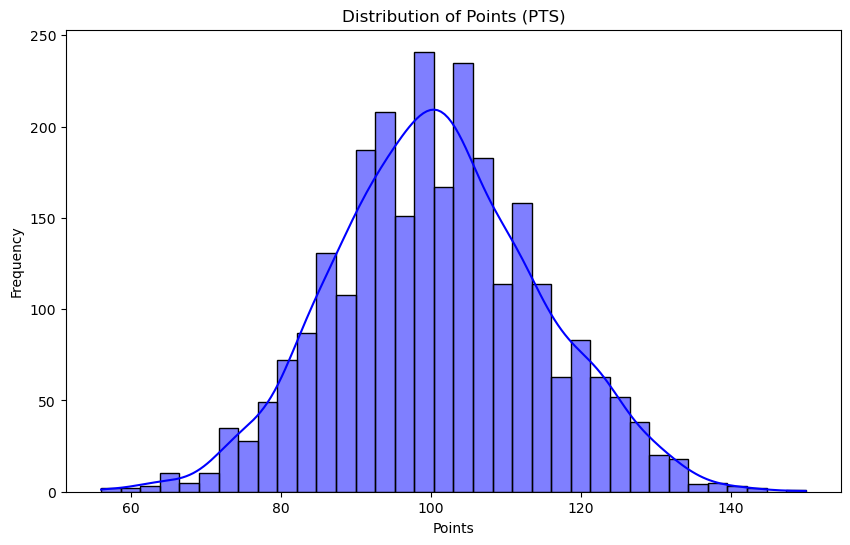

```python
plt.figure(figsize=(10, 6))
sns.histplot(tr_games['PTS'], kde=True, color="blue")
plt.title("Distribution of Points (PTS)")
plt.xlabel("Points")
plt.ylabel("Frequency")
plt.show()
```

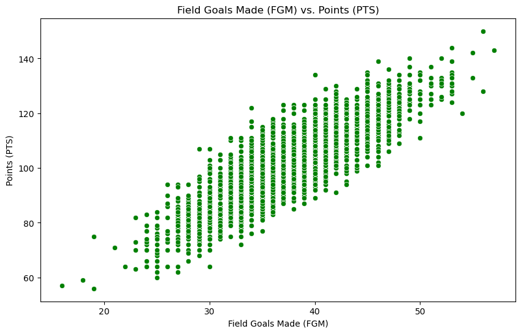

```python
plt.figure(figsize=(10, 6))
sns.scatterplot(data=tr_games, x='FGM', y='PTS', color="green")
plt.title("Field Goals Made (FGM) vs. Points (PTS)")
plt.xlabel("Field Goals Made (FGM)")
plt.ylabel("Points (PTS)")
plt.show()
```

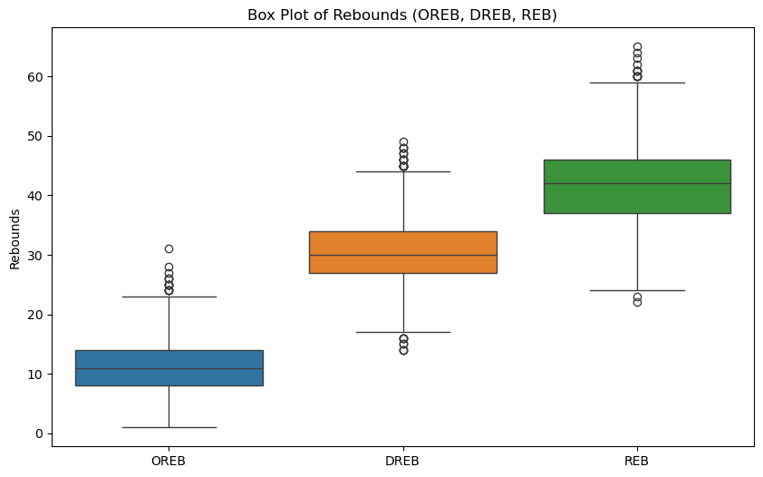

```python
plt.figure(figsize=(10, 6))
sns.boxplot(data=tr_games[['OREB', 'DREB', 'REB']])
plt.title("Box Plot of Rebounds (OREB, DREB, REB)")
plt.ylabel("Rebounds")
plt.show()
```

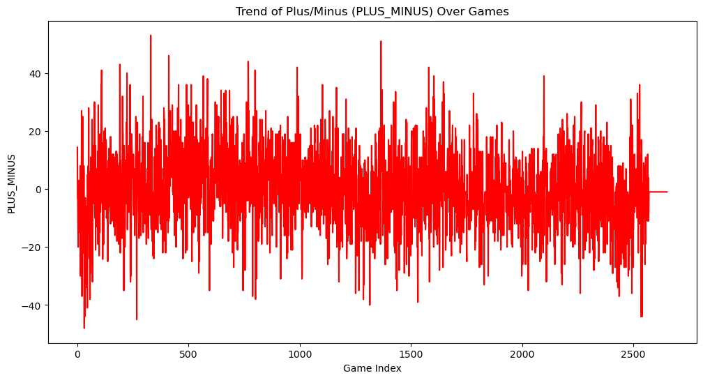

```python
plt.figure(figsize=(12, 6))
sns.lineplot(data=tr_games, x=tr_games.index, y='PLUS_MINUS', color="red")
plt.title("Trend of Plus/Minus (PLUS_MINUS) Over Games")
plt.xlabel("Game Index")
plt.ylabel("PLUS_MINUS")
plt.show()
```

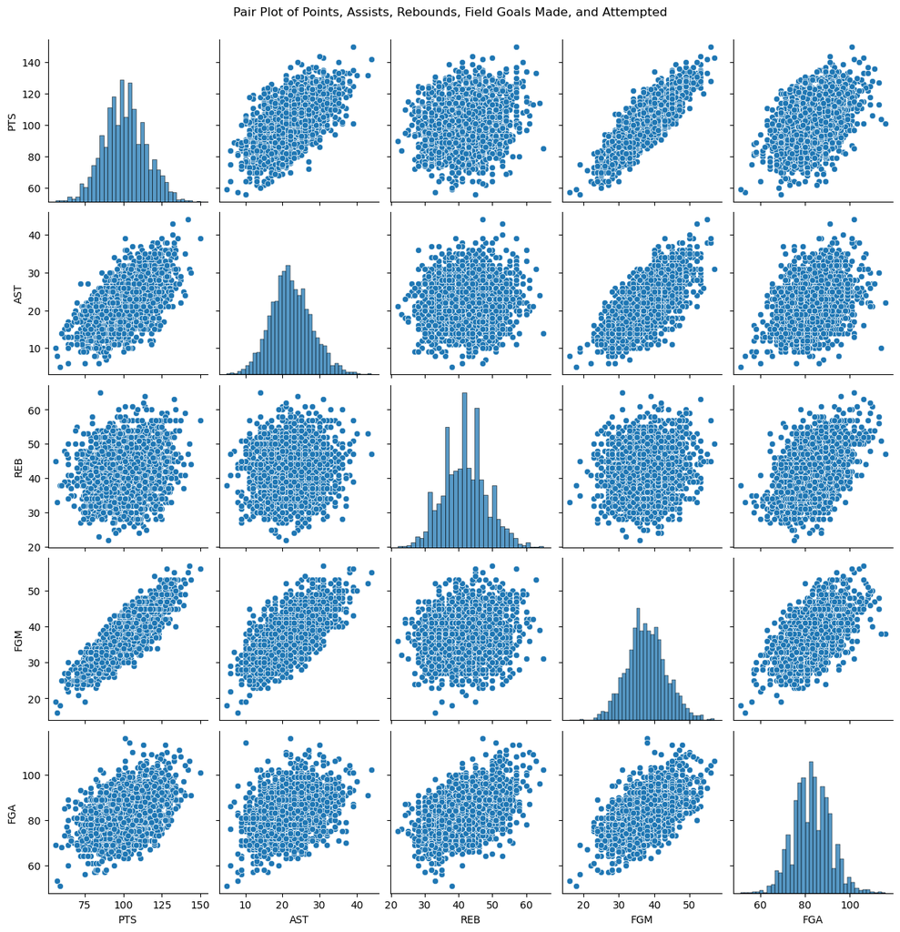

```python
# 6. Pair Plot for Selected Stats
plt.figure(figsize=(10, 8))
sns.pairplot(tr_games[['PTS', 'AST', 'REB', 'FGM', 'FGA']])
plt.suptitle("Pair Plot of Points, Assists, Rebounds, Field Goals Made, and Attempted", y=1.02)
plt.show()
```

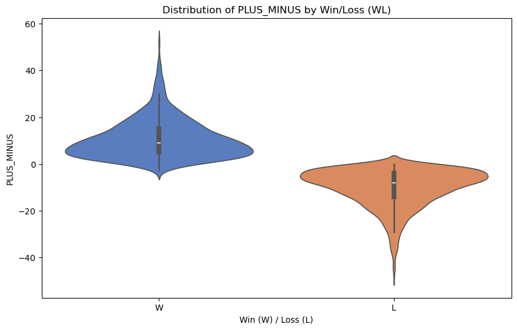

```python
#Violin Plot for Plus/Minus by Win or Loss (WL)
plt.figure(figsize=(10, 6))
sns.violinplot(data=tr_games, x='WL', y='PLUS_MINUS', palette="muted")
plt.title("Distribution of PLUS_MINUS by Win/Loss (WL)")
plt.xlabel("Win (W) / Loss (L)")
plt.ylabel("PLUS_MINUS")
plt.show()
```

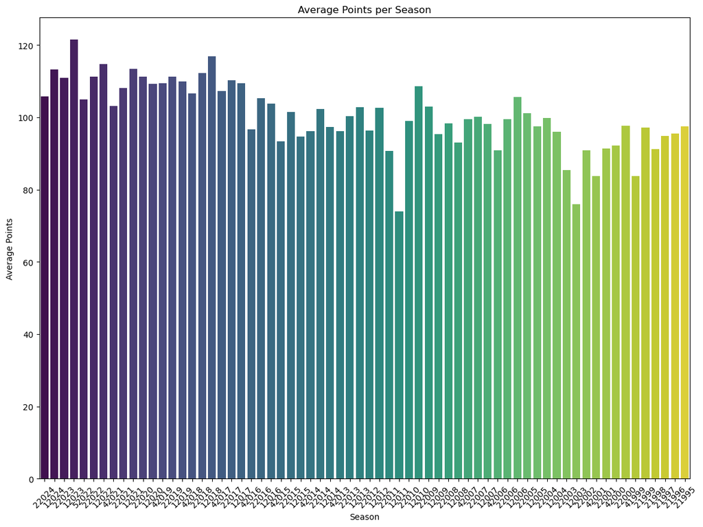

```python
# 8. Bar Plot of Average Points by Season
plt.figure(figsize=(14, 10))
sns.barplot(data=tr_games, x='SEASON_ID', y='PTS', estimator='mean', ci=None, palette="viridis")
plt.title("Average Points per Season")
plt.xlabel("Season")
plt.ylabel("Average Points")
plt.xticks(rotation=45)
plt.show()
```

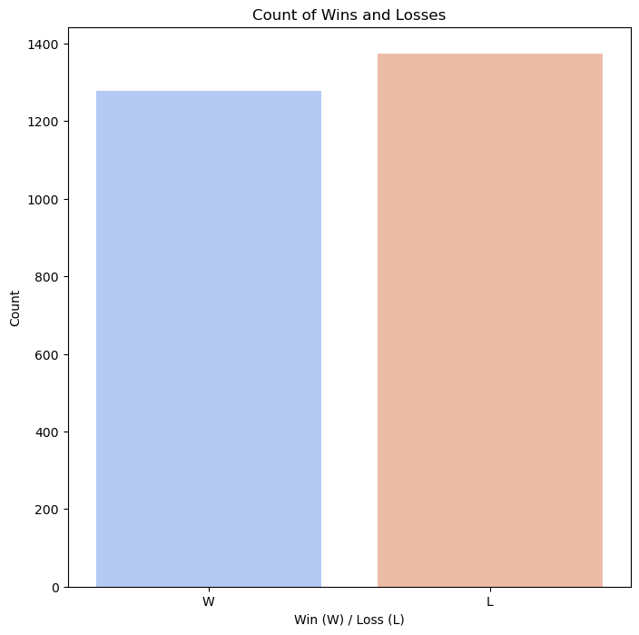

```python
# 9. Count Plot of Wins and Losses
plt.figure(figsize=(8, 8))
sns.countplot(data=tr_games, x='WL', palette="coolwarm")
plt.title("Count of Wins and Losses")
plt.xlabel("Win (W) / Loss (L)")
plt.ylabel("Count")
plt.show()
```

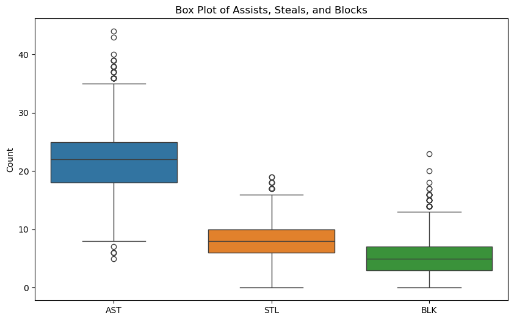

```python
# 11. Box Plot of Assists, Steals, and Blocks
plt.figure(figsize=(10, 6))
sns.boxplot(data=tr_games[['AST', 'STL', 'BLK']])
plt.title("Box Plot of Assists, Steals, and Blocks")
plt.ylabel("Count")
plt.show()
```

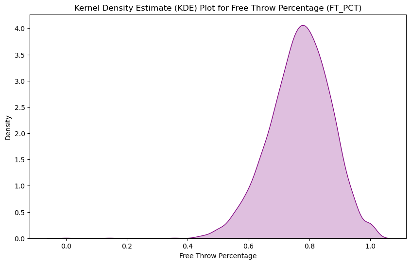

```python
# 12. KDE Plot for Free Throw Percentage
plt.figure(figsize=(10, 6))
sns.kdeplot(tr_games['FT_PCT'], color="purple", shade=True)
plt.title("Kernel Density Estimate (KDE) Plot for Free Throw Percentage (FT_PCT)")
plt.xlabel("Free Throw Percentage")
plt.ylabel("Density")
plt.show()
```